# R Notebook

```r
library(TSA)
library(forecast)
library(tseries)
source('functions.R')
data = read.csv('orders.csv')
```

Données : 308 jours (44 semaines) à partir du 4 janvier 2021

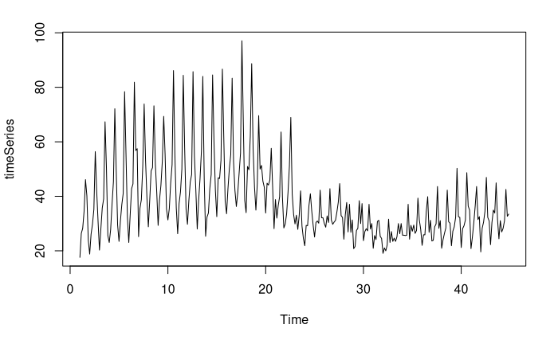

```r
timeSeries = ts(data$n_orders, frequency=7)
plot(timeSeries, type='l')
```

Données d’entrainement

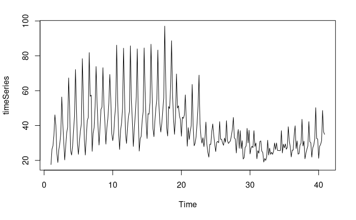

```r
timeSeriesTest = ts(data$n_orders[281:308], start = 41, frequency=7)
timeSeries = ts(data$n_orders[1:280], frequency=7)
plot(timeSeries, type='l')
```

La série n’est clairement pas stationnaire. On peut dans un premier temps tenter de réduire la variance par une transformation de BoxCox

```r
help(BoxCox)
```

```r
lambd = BoxCox.lambda(timeSeries, lower=-2, upper=2, method="loglik")
lambd
```

```
[1] -0.45
```

-1 : 8.9% (BoxCox.lambda(timeSeries)) -0.3 : 9.54% -0.7 : 8.9%

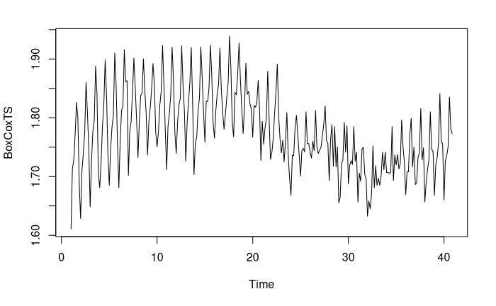

```r
BoxCoxTS = ts(BoxCox(timeSeries,lambd), start=1, frequency = 7)
plot(BoxCoxTS)
```

On a réussi à bien réduire la variance.

```r
kpss.test(BoxCoxTS)
```

```
p-value smaller than printed p-value
```

```
    KPSS Test for Level Stationarity

data:  BoxCoxTS
KPSS Level = 2.3862, Truncation lag parameter = 5, p-value = 0.01
```

```r
adf.test(BoxCoxTS)
```

```
    Augmented Dickey-Fuller Test

data:  BoxCoxTS
Dickey-Fuller = -2.6087, Lag order = 6, p-value = 0.3196
alternative hypothesis: stationary
```

Pas stationnaire

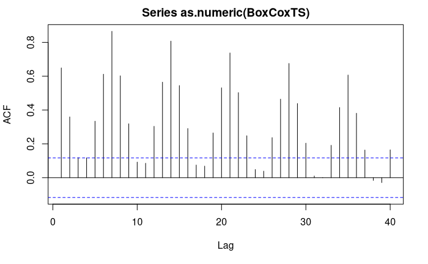

```r
acf(as.numeric(BoxCoxTS), lag.max=40)
```

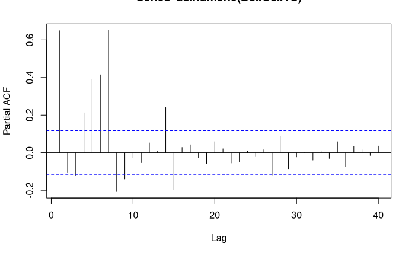

```r
pacf(as.numeric(BoxCoxTS), lag.max=40)
```

Differenciation I-B

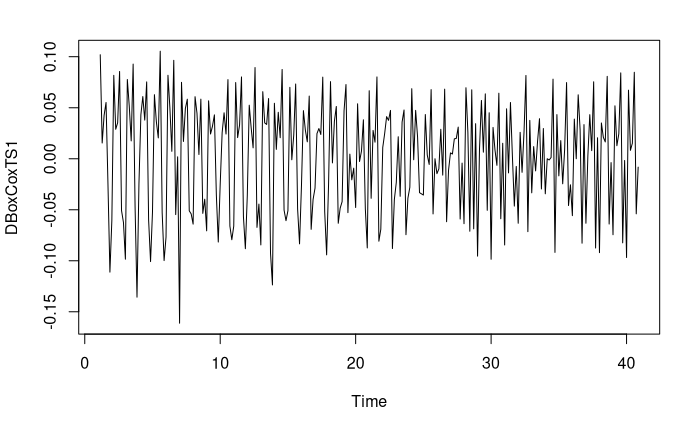

```r
DBoxCoxTS1 = diff(BoxCoxTS)
plot(DBoxCoxTS1)
```

```r
kpss.test(DBoxCoxTS1)
```

```
p-value greater than printed p-value
```

```
    KPSS Test for Level Stationarity

data:  DBoxCoxTS1
KPSS Level = 0.092485, Truncation lag parameter = 5, p-value = 0.1
```

```r
adf.test(DBoxCoxTS1)
```

```
p-value smaller than printed p-value
```

```
    Augmented Dickey-Fuller Test

data:  DBoxCoxTS1
Dickey-Fuller = -11.565, Lag order = 6, p-value = 0.01
alternative hypothesis: stationary
```

Les tests vont dans le sens de la stationnarité

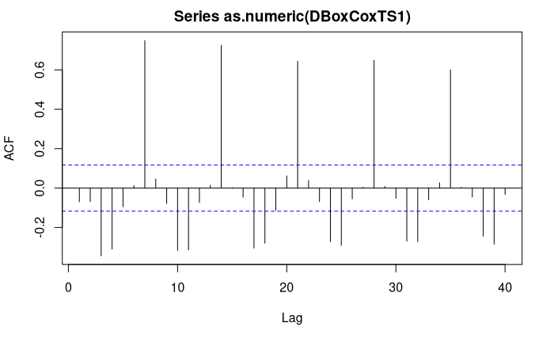

```r
acf(as.numeric(DBoxCoxTS1), lag.max=40)
```

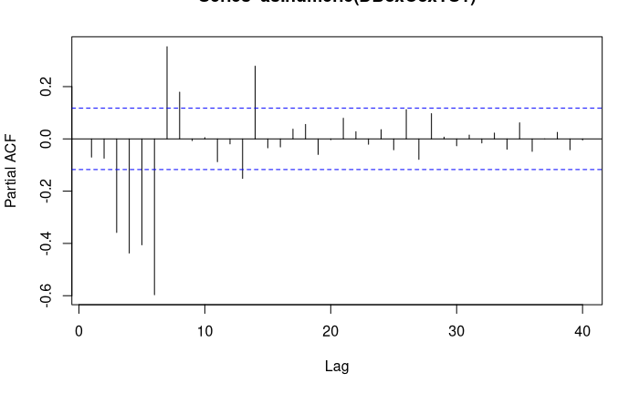

```r
pacf(as.numeric(DBoxCoxTS1), lag.max=40)
```

Mais pas l’ACF où un motif périodique se dessine clairement. On voit néanmois qu’on a réussi à éliminer la tendance.

Differenciation I-B⁷

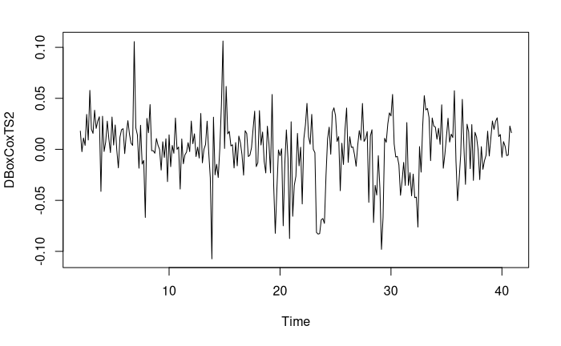

```r
DBoxCoxTS2 = diff(BoxCoxTS,7)
plot(DBoxCoxTS2)
```

```r
kpss.test(DBoxCoxTS2)
```

```
p-value greater than printed p-value
```

```
    KPSS Test for Level Stationarity

data:  DBoxCoxTS2
KPSS Level = 0.29581, Truncation lag parameter = 5, p-value = 0.1
```

```r
adf.test(DBoxCoxTS2)
```

```
p-value smaller than printed p-value
```

```
    Augmented Dickey-Fuller Test

data:  DBoxCoxTS2
Dickey-Fuller = -8.2681, Lag order = 6, p-value = 0.01
alternative hypothesis: stationary
```

Les tests vont dans le sens de la stationnarité

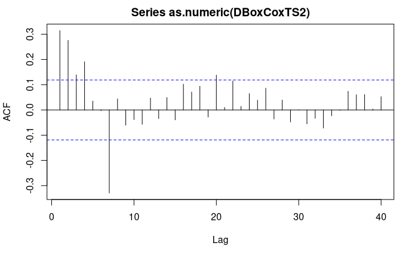

```r
acf(as.numeric(DBoxCoxTS2), lag.max=40)
```

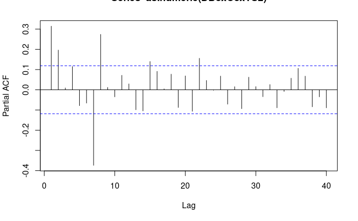

```r
pacf(as.numeric(DBoxCoxTS2), lag.max=40)
```

Differenciation (I-B)(I-B⁷)

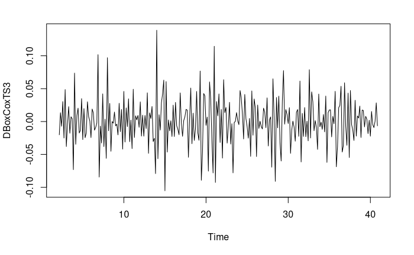

```r
DBoxCoxTS3 = diff(diff(BoxCoxTS,7))
plot(DBoxCoxTS3)
```

```r
kpss.test(DBoxCoxTS3)
```

```
p-value greater than printed p-value
```

```
    KPSS Test for Level Stationarity

data:  DBoxCoxTS3
KPSS Level = 0.014144, Truncation lag parameter = 5, p-value = 0.1
```

```r
adf.test(DBoxCoxTS3)
```

```
p-value smaller than printed p-value
```

```
    Augmented Dickey-Fuller Test

data:  DBoxCoxTS3
Dickey-Fuller = -9.7785, Lag order = 6, p-value = 0.01
alternative hypothesis: stationary
```

Les tests vont dans le sens de la stationnarité

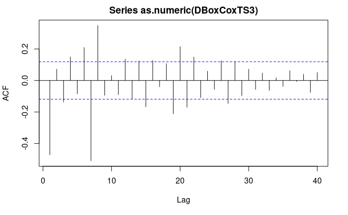

```r
acf(as.numeric(DBoxCoxTS3), lag.max=40)
```

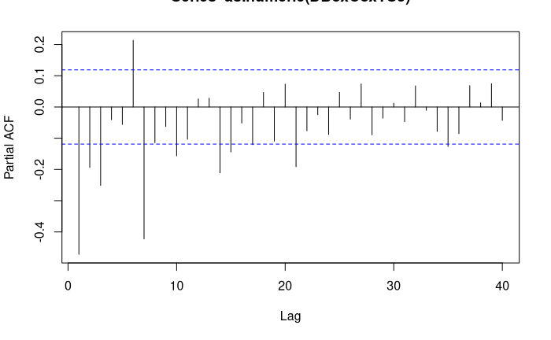

```r
pacf(as.numeric(DBoxCoxTS3), lag.max=40)
```

Conclusion : Il est judicieux de garder les séries DBoxCoxTS2 et DBoxCoxTS3 dont la stationnarité est soutenue par l’analyse visuelle et les tests ADF et KPSS. On notera aussi qu’on a éliminé les tendances et les saisonnalités sur ces séries.

Premier modèle :

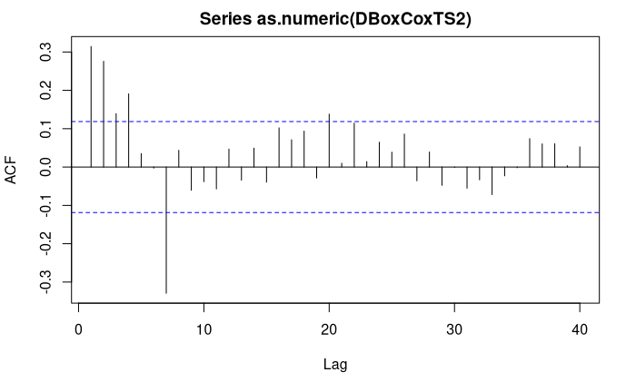

```r
acf(as.numeric(DBoxCoxTS2),lag.max = 40)
```

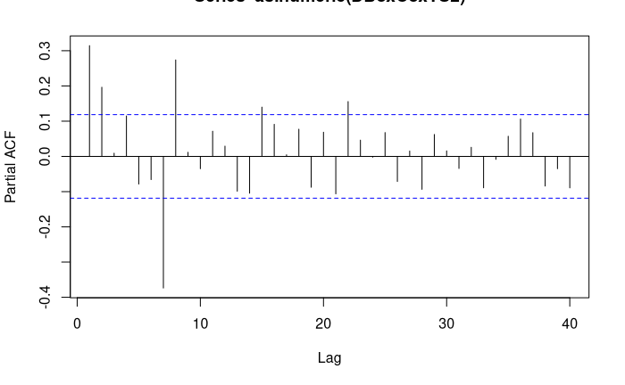

```r
pacf(as.numeric(DBoxCoxTS2),lag.max = 40)
```

```r
mod1 = auto.arima(BoxCoxTS,allowmean = TRUE, D = 1, d = 0, max.p = 8, max.q = 7, allowdrift = TRUE)
mod1
```

```
Series: BoxCoxTS
ARIMA(1,0,2)(2,1,2)[7]

Coefficients:
         ar1      ma1      ma2     sar1    sar2     sma1     sma2
      0.9652  -0.6110  -0.0990  -0.5932  0.0660  -0.1140  -0.4405
s.e.  0.0262   0.0654   0.0629   0.4960  0.0923   0.4937   0.3320

sigma^2 estimated as 0.0006047:  log likelihood=625.53
AIC=-1235.07   AICc=-1234.52   BIC=-1206.19
```

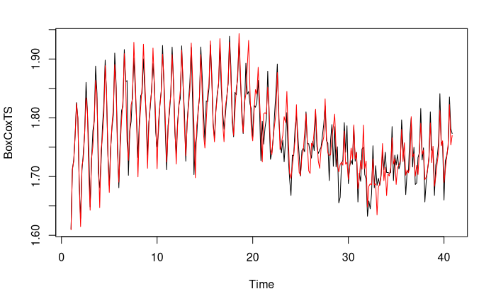

```r
plot(BoxCoxTS)
lines(mod1$fitted,col='red')
```

Second modèle :

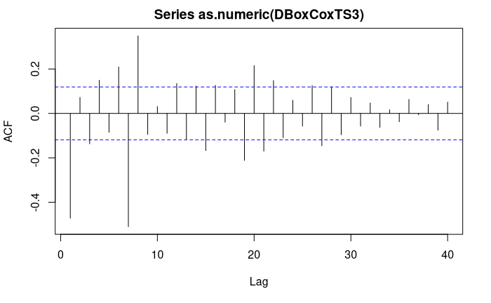

```r
acf(as.numeric(DBoxCoxTS3),lag.max = 40)
```

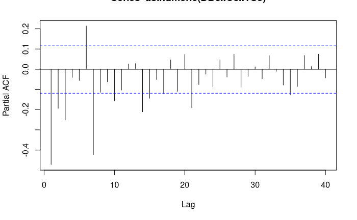

```r
pacf(as.numeric(DBoxCoxTS3),lag.max = 40)
```

```r
mod2 = auto.arima(BoxCoxTS,allowmean = TRUE, max.D = 1, max.d = 1, allowdrift = TRUE)
mod2
```

```
Series: BoxCoxTS
ARIMA(1,0,2)(2,1,2)[7]

Coefficients:
         ar1      ma1      ma2     sar1    sar2     sma1     sma2
      0.9652  -0.6110  -0.0990  -0.5932  0.0660  -0.1140  -0.4405
s.e.  0.0262   0.0654   0.0629   0.4960  0.0923   0.4937   0.3320

sigma^2 estimated as 0.0006047:  log likelihood=625.53
AIC=-1235.07   AICc=-1234.52   BIC=-1206.19
```

Erreur finale

```r
library(MLmetrics)
pred = forecast(mod1, h=28)

pred_val = boxcox.inv(pred$mean, lambd)
MAPE(pred_val, timeSeriesTest)
```

```
[1] 0.1045736
```

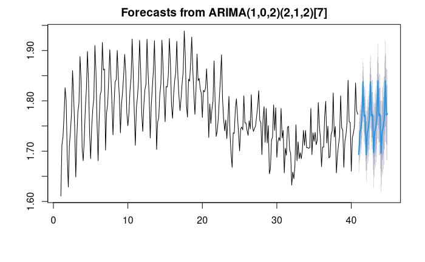

```r
plot(pred)
```